# Ramen Rating Project

Lin Miao

2021/6/4

**Members and Contributions:**

Lin Miao (linmiao@ucdavis.edu) : Data Cleaning and Outlier Removal; Visualizations; Statistical Analysis

Siyi Wei (sywei@ucdavis.edu): Data Cleaning and Outlier Removal; Visualizations; Statistical Analysis

Antonio Pelayo Ramirez (antpelayo@ucdavis.edu): Interpretation and Reporting

Billy Wang (mywang@ucdavis.edu): Interpretation and Reporting

Yicheng Xie (maxxie@ucdavis.edu ): Results and Interpretation

# A.Introduction

Ramen is a kind of food which is more and more popular and has shared larger and larger catering market in these decades. Handreds of kinds and brands of ramens are growing all over the world in different flavour. Thus it in interested that which kinds or brands of ramen are most popular, as well as why people prefer these kinds or brands of ramen. In this report, both visualization and numerical methods are used to investigate the questions proposed above.

To achieve this goal and construct the visualizations and models, We will explore ramen ratings data collected from“Big List” to see how brands, styles, and country of the production affect the ratings of the ramen. In this dataset, ratings of ramens are regarded as indicator of popularity and other variables such as brands, styles, and country metioned above are considered as predictors added into models.

# B.Background

The dataset used in this report, the Ramen Rater dataset, is a product review website for the hardcore ramen enthusiast (or “ramenphile”), with over 2500 reviews to date. Each record in the dataset is a single ramen product review. Review numbers are contiguous: more recently reviewed ramen varieties have higher numbers. Brand, Variety (the product name), Country, and Style (Cup? Bowl? Tray?) are pretty self-explanatory. Stars indicate the ramen quality, as assessed by the reviewer, on a 5-point scale, which is the the response variable in this report to measure the popularity of each kinds and brands of ramens.

The dataset is avaliable at webset (https://www.theramenrater.com/).

# C.Questions interested

Rating is an important indicator which tell us that how high the acceptablity is for a product. Thus in tis report, rating is also regarded as an inidcator to represent how successful the products are. Thus the most questions are proposed as:

- Which ramen has the highest rating?
- Which country does the highest rated ramen come from?
- Is there any relationship between variables?

# D.Study Design and Methodology

In this report we are going to first clean the data, remove ourliers and NA, remove low-weight observations, then we are going to use plots (histogram, bar plot, pie plot, boxplot) to visualize the data set and find important details with different factors. Finally, we are going to build regression model and use anova and hypothesis test to detect the relationships between variables in details.

## Data cleaning

Data clearning is an important preprocess in data analysis, which is an ensurement for accurcy and robustness of the following visualization and models contructed processes. In this report, steps of data cleaning indlude `NA` detected and removed, outliers detected and removed, irrevelant predictors removed and transformation for variables if deeded.

### (1) Cleaning for response variable

```
## tibble [2,580 x 5] (S3: tbl_df/tbl/data.frame)
##  $ Style   : Factor w/ 8 levels "","Bar","Bowl",..: 6 7 6 7 7 7 6 8 7 7 ...
##  $ Brand   : Factor w/ 355 levels "1 To 3 Noodles",..: 193 122 195 339 38 252 8 110 236 137 ...
##  $ Country : Factor w/ 38 levels "Australia","Bangladesh",..: 19 33 37 33 17 31 19 19 19 30 ...
##  $ Stars   : Named num [1:2580] 3.75 1 2.25 2.75 3.75 4.75 4 3.75 0.25 2.5 ...
##   ..- attr(*, "names")= chr [1:2580] "3.75" "1" "2.25" "2.75" ...
##  $ Review..: num [1:2580] 2580 2579 2578 2577 2576 ...
```

```
## tibble [2,554 x 5] (S3: tbl_df/tbl/data.frame)
##  $ Style   : Factor w/ 8 levels "","Bar","Bowl",..: 6 7 6 7 7 7 6 8 7 7 ...
##  $ Brand   : Factor w/ 355 levels "1 To 3 Noodles",..: 193 122 195 339 38 252 8 110 236 137 ...
##  $ Country : Factor w/ 38 levels "Australia","Bangladesh",..: 19 33 37 33 17 31 19 19 19 30 ...
##  $ Stars   : Named num [1:2554] 3.75 1 2.25 2.75 3.75 4.75 4 3.75 0.25 2.5 ...
##   ..- attr(*, "names")= chr [1:2554] "3.75" "1" "2.25" "2.75" ...
##  $ Review..: num [1:2554] 2580 2579 2578 2577 2576 ...
```

In this dataset, `NA` of response variable, `Stars`, is recorded as `Unrated`, which makes all of `Stars` variable into characters. Thus the first step is remove observations with `Unrated` and transform the `Stars` variable into numeric.

Besides, some observation is with `Stars` recorded as 0, which is abnormal due to the lowest rating should be 1. Thus to ensure reasonablity of the following visualization and models constructed these abnormal observations are also removed.

### (2) Removement of observations with low weights

```
## # A tibble: 1,560 x 5
##    Style Brand          Country     Stars Review..
##    <fct> <fct>          <fct>       <dbl>    <dbl>
##  1 Cup   New Touch      Japan        3.75     2580
##  2 Pack  Just Way       Taiwan       1        2579
##  3 Cup   Nissin         USA          2.25     2578
##  4 Pack  Wei Lih        Taiwan       2.75     2577
##  5 Pack  Ching's Secret India        3.75     2576
##  6 Pack  Samyang Foods  South Korea  4.75     2575
##  7 Cup   Acecook        Japan        4        2574
##  8 Tray  Ikeda Shoku    Japan        3.75     2573
##  9 Pack  Ripe'n'Dry     Japan        0.25     2572
## 10 Pack  KOKA           Singapore    2.5      2571
## # ... with 1,550 more rows
```

### (3) Removement of outliers

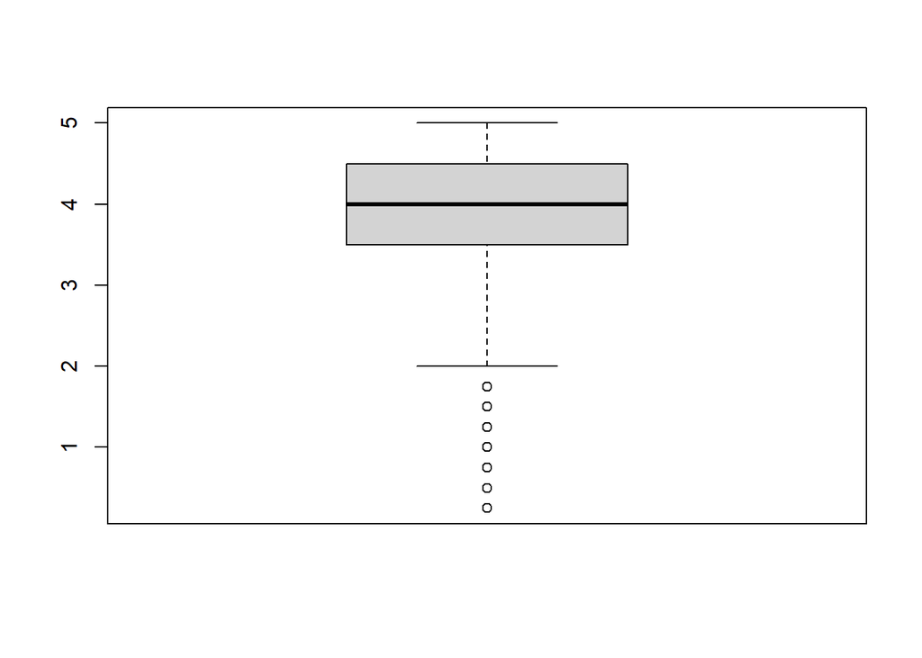

```
##    Min. 1st Qu.  Median    Mean 3rd Qu.    Max.
##   0.250   3.500   4.000   3.869   4.500   5.000
```

```
## # A tibble: 1,476 x 5
##    Style Brand          Country     Stars Review..
##    <fct> <fct>          <fct>       <dbl>    <dbl>
##  1 Cup   New Touch      Japan        3.75     2580
##  2 Cup   Nissin         USA          2.25     2578
##  3 Pack  Wei Lih        Taiwan       2.75     2577
##  4 Pack  Ching's Secret India        3.75     2576
##  5 Pack  Samyang Foods  South Korea  4.75     2575
##  6 Cup   Acecook        Japan        4        2574
##  7 Tray  Ikeda Shoku    Japan        3.75     2573
##  8 Pack  KOKA           Singapore    2.5      2571
##  9 Pack  Tao Kae Noi    Thailand     5        2570
## 10 Pack  Yamachan       USA          5        2569
## # ... with 1,466 more rows
```

In this report, outliers are detected according to boxplot, in which observations with rating higher than $3rd\ quantile+1.5IQR$ and less than $1st\ quantile-1.5IQR$ are regarded as outliers. As a result, it is revealed that no ratings of these observations are higher than $3rd\ quantile+1.5IQR$ but a few of them are less than $1st\ quantile-1.5IQR$. Thus these observations are removed as outliers.

As a result, after data cleaning in which `NA`s, ignorable observation with low weights and outliers are removed, the number of observations is changed from 2580 to 1476. The cleaned dataset is not including any `NA`s and abnormal or unimportant observations.

## Visualizations and Analysis (explain each plot)

```
##
##    5    4  3.5 3.75    3  4.5 4.25 3.25 4.75 2.75  2.5 2.25  4.3  3.8  2.3  3.3
##  325  289  203  203   96   85   84   79   38   32   25    8    4    3    1    1
```

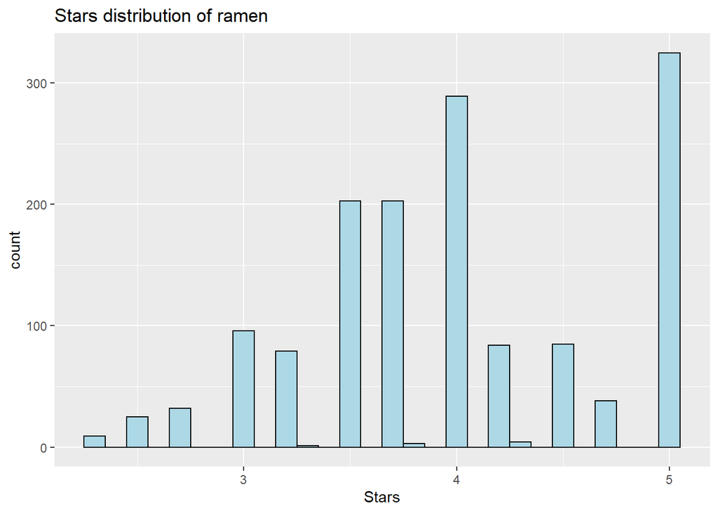

Before model constructed, the first thing is to determine the distribution of response variable. In this report, histogram is used to visualize the distribution of rating. Through this histogram, we can clearly observe the general distribution of the ramen scores. We found that most of the ramen scores are between 3 and 5. Among them, there are 289 ramen scores are 4 stars, and there are 325 scores are 5 stars. Indeed, there are some outliers with lower scores. For example, 2.3-stars. Besides according to the figure, it indicates that the distribution of rating is almost a symmetric bell curve as normality expect rating is 5 star. It is because the maximum rating is 5, which cause the inflation of counts for 5 stars. Thus the count of 5-star is too high in the histogram. In summary, the response variable, `Stars`, is almost normality with high-value inflation.

```
##
##         Japan      Malaysia        Taiwan           USA   South Korea
##           228           141           141           126           121
##     Hong Kong      Thailand         China     Singapore     Indonesia
##           107            99            95            92            55
##            UK       Vietnam       Germany        Mexico         India
##            30            29            27            25            21
##        Canada     Australia       Myanmar         Nepal   Philippines
##            17            16            14            13            12
##   Netherlands       Hungary    Bangladesh      Pakistan      Colombia
##            10             9             7             7             6
##        Brazil      Cambodia       Finland       Sarawak        Sweden
##             5             5             3             3             3
##       Estonia          Fiji         Ghana       Holland        Poland
##             2             2             2             1             1
## United States         Dubai       Nigeria
##             1             0             0
```

```
##
## Pack  Cup Bowl Tray  Box  Bar  Can
##  898  303  230   38    5    1    1    0
```

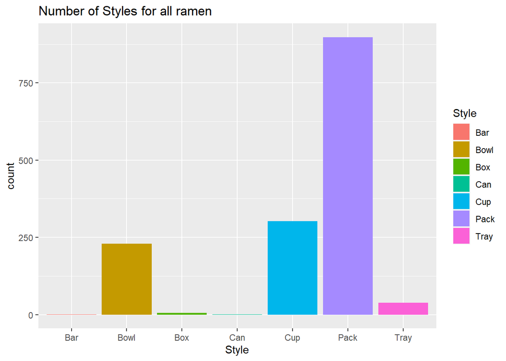

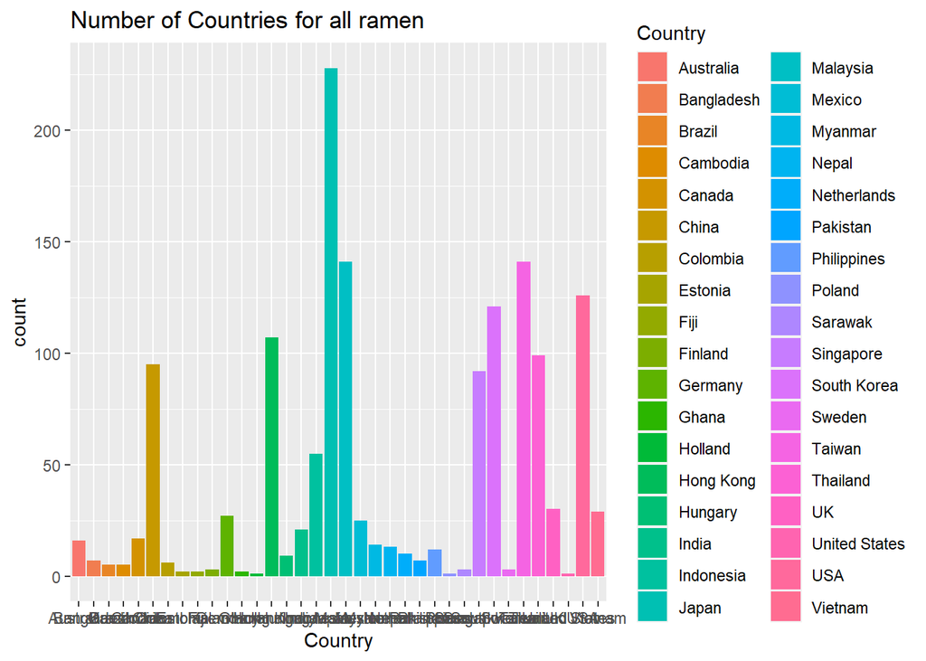

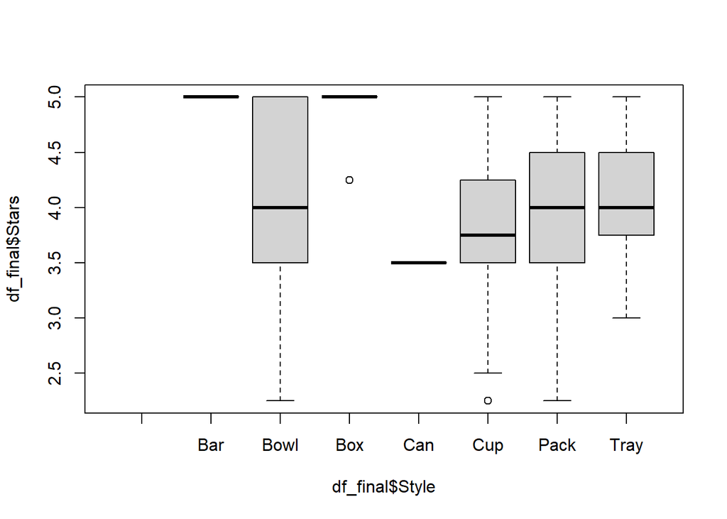

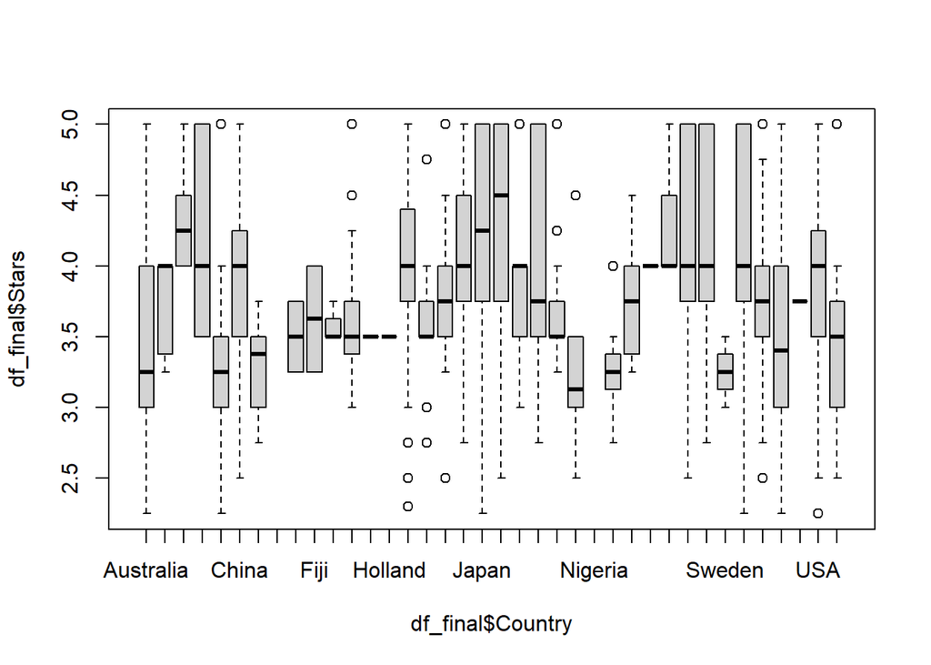

The main questions of the report is focused on the popularity of remains in styles or country. Thus at first, it is interesting that how ramen distributed around the world and how styles of ramen distributed for themself. The sort of counts of observations across countries and styles are sorted above. As a result, ramen is widely popular in Asian contries and regions such as Janpan, Malaysia Taiwan and South Korea. USA is the only one of Top 5 which is not Asian country.

As for style of ramen, it is found that the top 3 styles are absolutely dominant which include Pack, Cup and Bowl. The Pack ramen occupies about more than 60% ramen marketing.

The counts of each style and country are visualized as bar plots and the distribution for rating across styles and countries are visualized on boxplot. As the boxplot shown, the median of Pack, Cup and Bowl, the top-3 styles, are close, which idnciates that style of ramens may not affect the rating. However boxplots for ratings across countries are indicates that median of ratings for country is changed. Thus countries may be a factor to affect the rating.

```
##
##         Japan      Malaysia        Taiwan   South Korea     Singapore
##            63            53            47            33            31
##           USA     Hong Kong      Thailand         China     Indonesia
##            22            21            17            11             6
##       Myanmar            UK      Cambodia        Canada         India
##             4             4             2             2             2
##     Australia        Brazil       Germany        Mexico         Nepal
##             1             1             1             1             1
##       Sarawak       Vietnam    Bangladesh      Colombia         Dubai
##             1             1             0             0             0
##       Estonia          Fiji       Finland         Ghana       Holland
##             0             0             0             0             0
##       Hungary   Netherlands       Nigeria      Pakistan   Philippines
##             0             0             0             0             0
##        Poland        Sweden United States
##             0             0             0
```

```
##
## Pack Bowl  Cup Tray  Box  Bar       Can
##  192   64   56    8    4    1    0    0
```

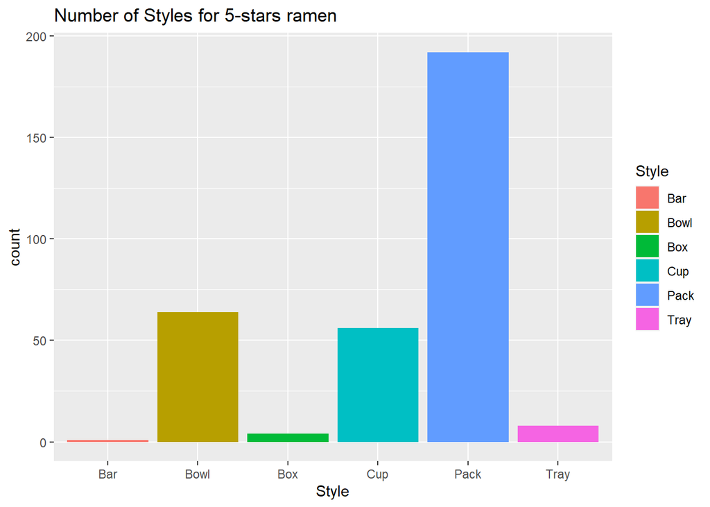

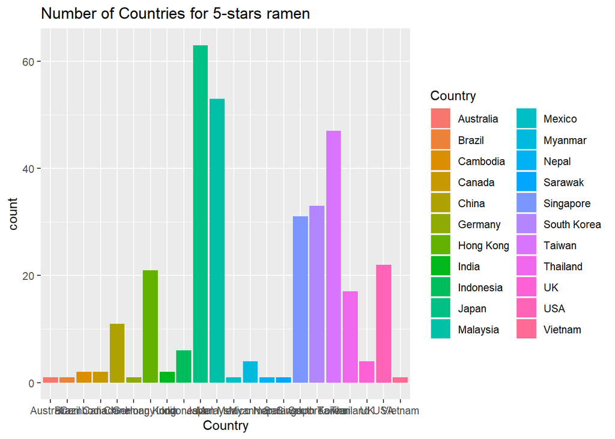

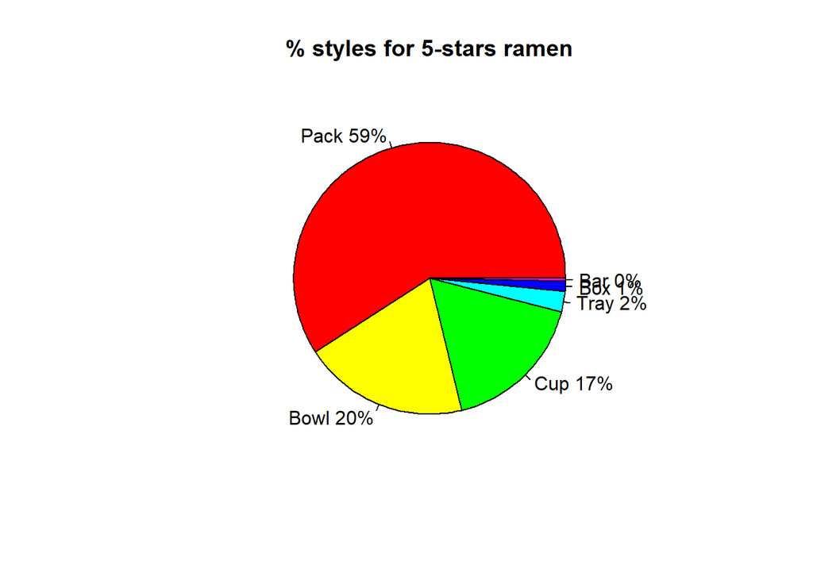

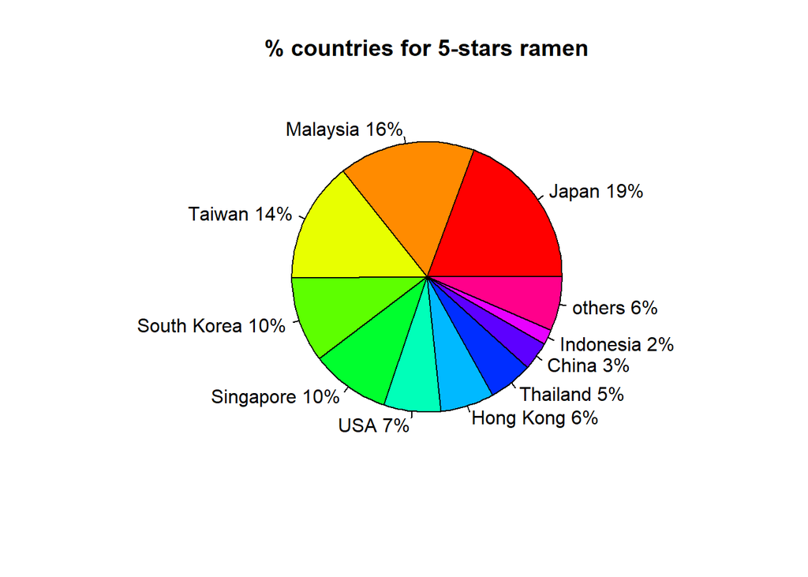

Furthermore, In this time, only observations with 5-star rating is retained rather than all observations for the dataset. It is found that among the ramen with a score of 5, we can conclude from bar plot that most of the ramen are packed, there are 192 packed ramen and 64 bowl ramen, and 56 cup ramen.On the other hand, from the bar plot and pie graph, on the country side, most of the 5-stars ramen are from Japan, Malaysia, Taiwan, Singapore and South Korea. This shows that Southeast Asian countries have this unique advantage in making ramen with unique flavors.

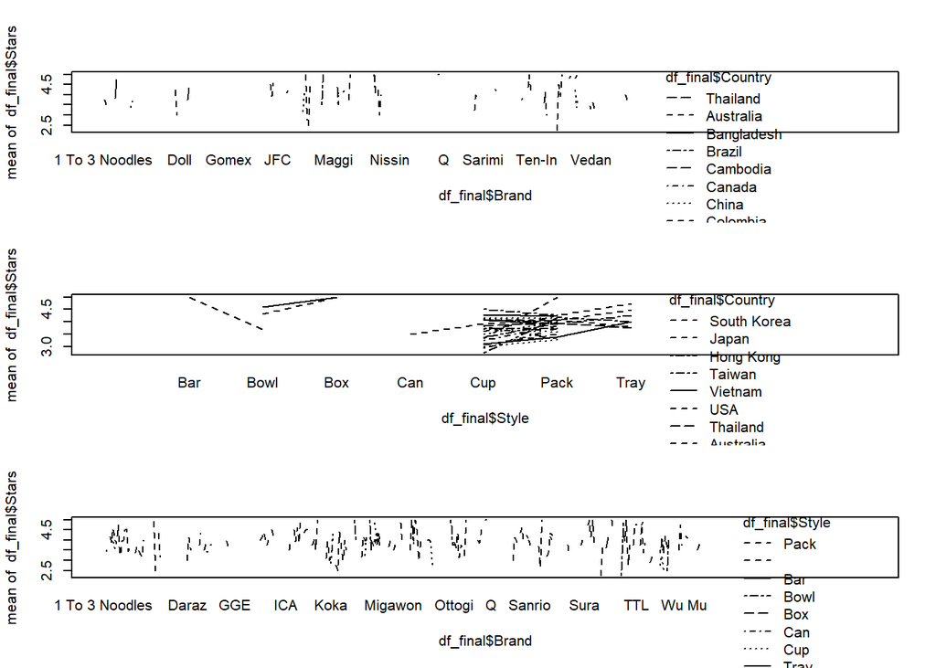

Due to level of Brand and countries are too many, it is hard to find significant information on interaction plot.

## Regression models

Visualizations are directly enough but not precise enough due to without any numeric results. Thus to make the results precise and objective enough, linear regression models are constructed here.

```
##
## Pack Bowl  Cup Tray  Box
##  192   64   56    8    4
```

```
##
##       Japan    Malaysia      Taiwan South Korea   Singapore
##          63          53          47          33          31
```

```
##
## Call:
## lm(formula = Stars ~ factor(Style), data = df_final)
##
## Residuals:
##      Min       1Q   Median       3Q      Max
## -1.86783 -0.52355 -0.02355  0.47645  1.13383
##
## Coefficients:
##                   Estimate Std. Error t value Pr(>|t|)
## (Intercept)         5.0000     0.6888   7.259 6.31e-13 ***
## factor(Style)Bowl  -0.8822     0.6903  -1.278    0.201
## factor(Style)Box   -0.1500     0.7546  -0.199    0.842
## factor(Style)Can   -1.5000     0.9741  -1.540    0.124
## factor(Style)Cup   -1.1338     0.6900  -1.643    0.101
## factor(Style)Pack  -0.9764     0.6892  -1.417    0.157
## factor(Style)Tray  -0.9013     0.6978  -1.292    0.197
## ---
## Signif. codes:  0 '***' 0.001 '**' 0.01 '*' 0.05 '.' 0.1 ' ' 1
##
## Residual standard error: 0.6888 on 1469 degrees of freedom
## Multiple R-squared:  0.01993,    Adjusted R-squared:  0.01593
## F-statistic: 4.978 on 6 and 1469 DF,  p-value: 4.661e-05
```

```
##                                Estimate   t.value     Pr...t..
## (Intercept)                        4.00  6.545452 8.711249e-11
## factor(Brand)Tesco                -1.75 -2.024896 4.309532e-02
## factor(Brand)Tokachimen Koubou    -1.75 -2.024896 4.309532e-02
```

```
##                             Estimate   t.value     Pr...t..
## (Intercept)                3.4406250 20.912038 5.159355e-85
## factor(Country)Brazil      0.9093750  2.696978 7.078806e-03
## factor(Country)Cambodia    0.7593750  2.252116 2.446510e-02
## factor(Country)China       0.4699013  2.642202 8.326146e-03
## factor(Country)Hong Kong   0.5462909  3.096865 1.993554e-03
## factor(Country)Indonesia   0.6139205  3.284152 1.047460e-03
## factor(Country)Japan       0.7508224  4.411322 1.103838e-05
## factor(Country)Malaysia    0.8217863  4.733449 2.424570e-06
## factor(Country)Myanmar     0.5058036  2.100121 3.589179e-02
## factor(Country)Sarawak     0.8927083  2.156018 3.124743e-02
## factor(Country)Singapore   0.7197011  4.037320 5.691081e-05
## factor(Country)South Korea 0.7659866  4.375348 1.299712e-05
## factor(Country)Taiwan      0.7444814  4.288176 1.921361e-05
## factor(Country)Thailand    0.4457386  2.513668 1.205666e-02
## factor(Country)USA         0.4819940  2.759572 5.861036e-03
```

Finally, to investigate whether country would affect rating of ramens, the model with `Stars` as represent and `Country` as predictor is also constructed. Similarly with brand, it is revealed that P vlaues for some coefficients are less than 0.05, which indicates that rating is also affected by country significantly like brand predictor.

Then we use anova table and hypothesis test to test the relationship and interaction between variables:

1. Style vs Stars

```r
anova(lm(data = df,Stars ~ Style))
```

```
## Analysis of Variance Table
##
## Response: Stars
##             Df Sum Sq Mean Sq F value    Pr(>F)
## Style        6  14.17 2.36212  4.9783 4.661e-05 ***
## Residuals 1469 697.01 0.47448
## ---
## Signif. codes:  0 '***' 0.001 '**' 0.01 '*' 0.05 '.' 0.1 ' ' 1
```

As the p value is less than .05 so the relation between Stars and Style is significant.

2. Brand vs Stars

```r
anova(lm(data = df,Stars ~ Brand))
```

```
## Analysis of Variance Table
##
## Response: Stars
##             Df Sum Sq Mean Sq F value  Pr(>F)
## Brand        6   8.44 1.40711  2.9414 0.00741 **
## Residuals 1469 702.74 0.47838
## ---
## Signif. codes:  0 '***' 0.001 '**' 0.01 '*' 0.05 '.' 0.1 ' ' 1
```

As the p value is less than .05 so the relation between Stars and Brand is significant.

3. Country vs Stars Do variables have interaction?

```r
anova(lm(data = df,Stars ~ Country+Country:Style+Country:Brand))
```

```
## Analysis of Variance Table
##
## Response: Stars
##                 Df Sum Sq Mean Sq F value    Pr(>F)
## Country          9  63.37  7.0410 16.7846 < 2.2e-16 ***
## Country:Style   32  22.62  0.7068  1.6848   0.01004 *
## Country:Brand   21  32.45  1.5454  3.6840 3.978e-08 ***
## Residuals     1413 592.74  0.4195
## ---
## Signif. codes:  0 '***' 0.001 '**' 0.01 '*' 0.05 '.' 0.1 ' ' 1
```

As the p value is less than .05 so the relation between Stars and Country is significant and there is a significant interaction between country and style, country and brand.

1. Does variable Country and Brand have interaction?

```r
anova(lm(data = df,Stars ~ Country:Brand))
```

```
## Analysis of Variance Table
##
## Response: Stars
##                 Df Sum Sq Mean Sq F value    Pr(>F)
## Country:Brand   30  93.19 3.10624   7.263 < 2.2e-16 ***
## Residuals     1445 618.00 0.42768
## ---
## Signif. codes:  0 '***' 0.001 '**' 0.01 '*' 0.05 '.' 0.1 ' ' 1
```

As the p.value is less than .05 so the interaction between country and brand is significant.

2. Does variable Country and Style have interaction?

```r
anova(lm(data = df,Stars ~ Country:Style))
```

```
## Analysis of Variance Table
##
## Response: Stars
##                 Df Sum Sq Mean Sq F value    Pr(>F)
## Country:Style   41  85.99 2.09720  4.8103 < 2.2e-16 ***
## Residuals     1434 625.20 0.43598
## ---
## Signif. codes:  0 '***' 0.001 '**' 0.01 '*' 0.05 '.' 0.1 ' ' 1
```

As the p.value is less than .05 so the interaction beteen country and style is significant.

```r
anova(lm(data = df,Stars ~ Country:Brand))
```

```
## Analysis of Variance Table
##
## Response: Stars
##                 Df Sum Sq Mean Sq F value    Pr(>F)
## Country:Brand   30  93.19 3.10624   7.263 < 2.2e-16 ***
## Residuals     1445 618.00 0.42768
## ---
## Signif. codes:  0 '***' 0.001 '**' 0.01 '*' 0.05 '.' 0.1 ' ' 1
```

As the p.value is less than .05 so the interaction between country and Brand is significant.